# Tidy Tuesday - Bees

Richard Ryan

2022-05-21

```r
library(tidyverse)
library(scales)
library(infer)
library(moments)
```

Read in the datasets:

```r
colony <- read_csv("colony.csv")
stressor <- read_csv("stressor.csv")
```

Join the datasets:

```r
bees <- stressor %>%
   left_join(colony, by = c("year", "months", "state"))
```

We can now try to make sense of our data.

# 1 Data Cleaning

```r
glimpse(bees)
```

```
## Rows: 7,332
## Columns: 12
## $ year            <dbl> 2015, 2015, 2015, 2015, 2015, 2015, 2015, 2015, 2015, …
## $ months          <chr> "January-March", "January-March", "January-March", "Ja…
## $ state           <chr> "Alabama", "Alabama", "Alabama", "Alabama", "Alabama",…
## $ stressor        <chr> "Varroa mites", "Other pests/parasites", "Disesases", …
## $ stress_pct      <dbl> 10.0, 5.4, NA, 2.2, 9.1, 9.4, 26.9, 20.5, 0.1, NA, 1.8…
## $ colony_n        <dbl> 7000, 7000, 7000, 7000, 7000, 7000, 35000, 35000, 3500…
## $ colony_max      <dbl> 7000, 7000, 7000, 7000, 7000, 7000, 35000, 35000, 3500…
## $ colony_lost     <dbl> 1800, 1800, 1800, 1800, 1800, 1800, 4600, 4600, 4600, …
## $ colony_lost_pct <dbl> 26, 26, 26, 26, 26, 26, 13, 13, 13, 13, 13, 13, 11, 11…
## $ colony_added    <dbl> 2800, 2800, 2800, 2800, 2800, 2800, 3400, 3400, 3400, …
## $ colony_reno     <dbl> 250, 250, 250, 250, 250, 250, 2100, 2100, 2100, 2100, …
## $ colony_reno_pct <dbl> 4, 4, 4, 4, 4, 4, 6, 6, 6, 6, 6, 6, 1, 1, 1, 1, 1, 1, …
```

We can see that we have data for each state separately and that the data is split into quarters. For now let’s leave the `year` and `months` variables and focus on `state`. What we will notice is that there is a values for `United States` which is presumably a summary of the data for the individual states.

The problem is that we can’t really take the summary information on trust here, and we can always calculate this data ourselves. Therefore we shall `filter()` these values out:

```r
bees <- bees %>%
   filter(state != "United States")
```

Next let’s consider missing values:

```r
bees %>%
   summarise(across(everything(), ~sum(is.na(.x)))) %>%
   pivot_longer(cols = everything(),
                names_to = "variable",
                values_to = "totals") %>%
   arrange(-totals)
```

```
## # A tibble: 12 × 2
##    variable        totals
##    <chr>            <int>
##  1 colony_reno_pct   1554
##  2 stress_pct         837
##  3 colony_reno        780
##  4 colony_added       492
##  5 colony_lost_pct    318
##  6 colony_n           276
##  7 colony_max         276
##  8 colony_lost        276
##  9 year                 0
## 10 months               0
## 11 state                0
## 12 stressor             0
```

The `colony_n` feature is essential to any kind of analysis, so we can drop any `NA` values here:

```r
bees <- bees %>%
   drop_na(colony_n)
```

The `colony_lost_pct` and the `colony_reno_pct` are easily imputed:

```r
bees <- bees %>%
   mutate(colony_lost_pct = if_else(
      is.na(colony_lost_pct),
      100 * (colony_lost / colony_n),
      colony_lost_pct
   ))

bees <- bees %>%
   mutate(colony_reno_pct = if_else(
      is.na(colony_reno_pct),
      100 * (colony_reno / colony_n),
      colony_reno_pct
   ))
```

All other `NA`s can be replaced with zero:

```r
bees <- bees %>%
   mutate(across(where(is.numeric), ~replace_na(.x, 0)))
```

Two final corrections: (1) there is a spelling mistake in the `stressor` values; and (2) we need to convert the `stressor` variable to a factor for plotting:

```r
stressor_levels <- c("Varroa Mites", "Other Pests", "Pesticides", "Other", "Unknown", "Disease")
```

```r
bees <- bees %>%
   mutate(stressor = case_when(
      stressor == "Other pests/parasites" ~ "Other Pests",
      stressor == "Disesases" ~ "Disease",
      TRUE ~ stressor
   )) %>%
   mutate(stressor = str_to_title(stressor)) %>%
   mutate(stressor = factor(stressor, levels = stressor_levels))
```

Perhaps the most obvious problem with this data is that the colony numbers for each state are highly variable from one quarter to the next. Certainly this variability isn’t explained by the accompanying metrics for `colony_added`, `colony_lost` and `colony_reno`. A possible reason for these figures is the tendency for bee-keepers to move their colonies across state lines from one season to another.

What this means is that we can’t afford to be too fine-grained in our analysis with regard to individual states.

# 2 Exploratory Data Analysis

First let’s look at the various threats facing bee populations.

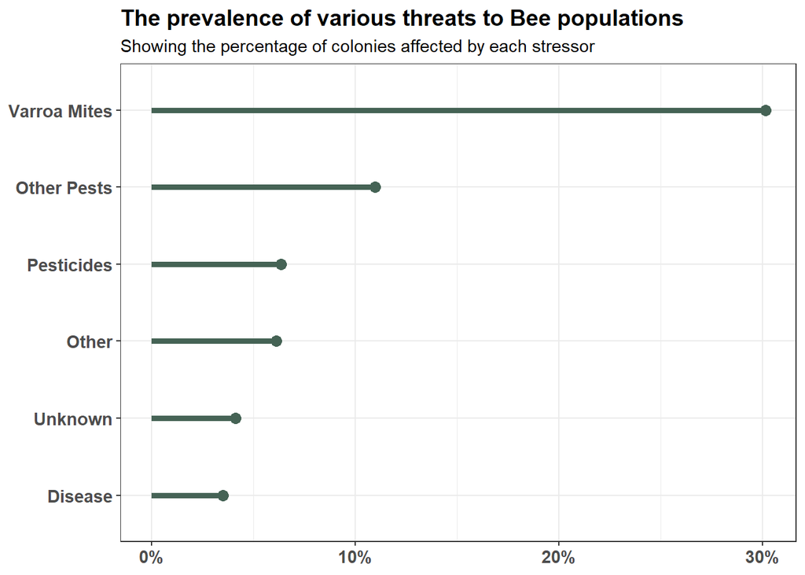

```r
bees %>%
   group_by(stressor) %>%
   mutate(
      totals = n(),
      total_pct_stressors = round(sum(stress_pct / totals), 2)
   ) %>%
   ungroup() %>%
   select(stressor, total_pct_stressors) %>%
   distinct() %>%
   mutate(stressor = factor(stressor, levels = stressor_levels)) %>%
   ggplot(aes(x = fct_rev(stressor), y = total_pct_stressors, fill = stressor)) +
   geom_point(size = 3, colour = "#456355", show.legend = FALSE) +
   geom_segment(
      aes(x = stressor, xend = stressor, y = 0, yend = total_pct_stressors),
      colour = "#456355",
      size = 1.75
   ) +
   theme_bw() +
   scale_y_continuous(labels = label_percent(scale = 1)) +
   labs(x = NULL, y = NULL,
        title = "The prevalence of various threats to Bee populations",
        subtitle = "Showing the percentage of colonies affected by each stressor") +
   theme(axis.text.x = element_text(face = "bold", size = 11),
         axis.text.y = element_text(face = "bold", size = 11),
         plot.title = element_text(face = "bold", size = 14)) +
   coord_flip()
```

How have the above threats translated into the number of bee colonies? We can see by comparing the `colony_added` and the `colony_lost` features for each year. Here let’s first calculate the total of bee colonies gained and lost across all states for each year; then we can use `cumsum()` to calculate the cumulative sum across the whole of our data.

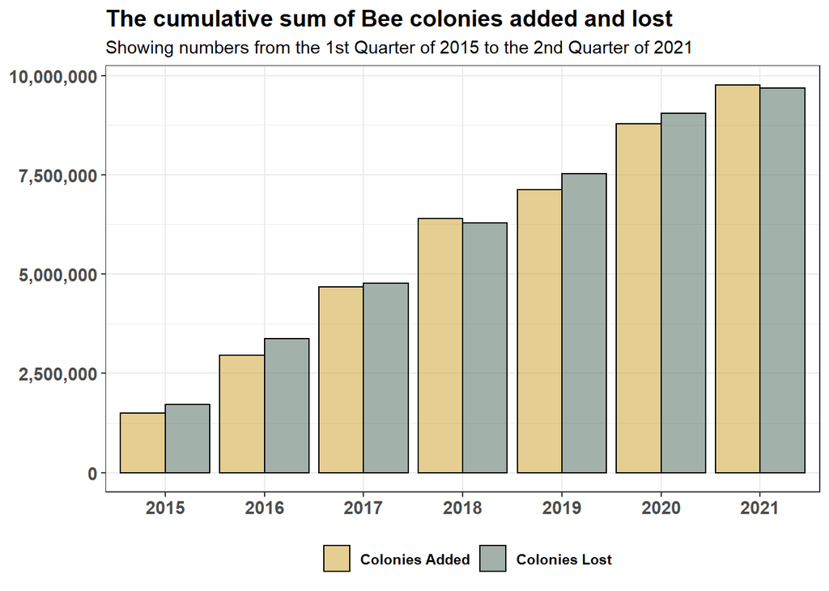

```r
bees %>%
   select(year, colony_added, colony_lost) %>%
   distinct() %>%
   group_by(year) %>%
   mutate(colony_added = sum(colony_added),
          colony_lost = sum(colony_lost)) %>%
   ungroup() %>% distinct() %>%
   mutate(colony_added = cumsum(colony_added),
          colony_lost = cumsum(colony_lost)) %>%
   pivot_longer(cols = starts_with("col"),
                names_to = "type",
                values_to = "value") %>%
   ggplot(aes(x = as.character(year), y = value, fill = type)) +
   geom_col(position = position_dodge(), alpha = 0.5, colour = "black") +
   theme_bw() +
   scale_fill_manual(values = c("#CB9E23", "#456355"),
                     labels = c("Colonies Added", "Colonies Lost")) +
   scale_y_continuous(labels = label_comma()) +
   labs(x = NULL, y = NULL,
        title = "The cumulative sum of Bee colonies added and lost",
        subtitle = "Showing numbers from the 1st Quarter of 2015 to the 2nd Quarter of 2021") +
   theme(axis.text.x = element_text(size = 11, face = "bold"),
         axis.text.y = element_text(size = 11, face = "bold"),
         plot.title = element_text(size = 14, face = "bold"),
         legend.text = element_text(face = "bold"),
         legend.title = element_blank(),
         legend.position = "bottom")
```

As we can see, the total number of bees added is slightly more than the total lost.

Of course we shouldn’t use this finding to lend support to the idea that there isn’t a problem. Clearly the loss of such large numbers of bees would be disastrous without bee-keepers making very significant interventions. Indeed, one of the problem with the above plot is that it doesn’t show just how volatile the bee population actually is.

Consider the following graph that shows quarterly gains and losses:

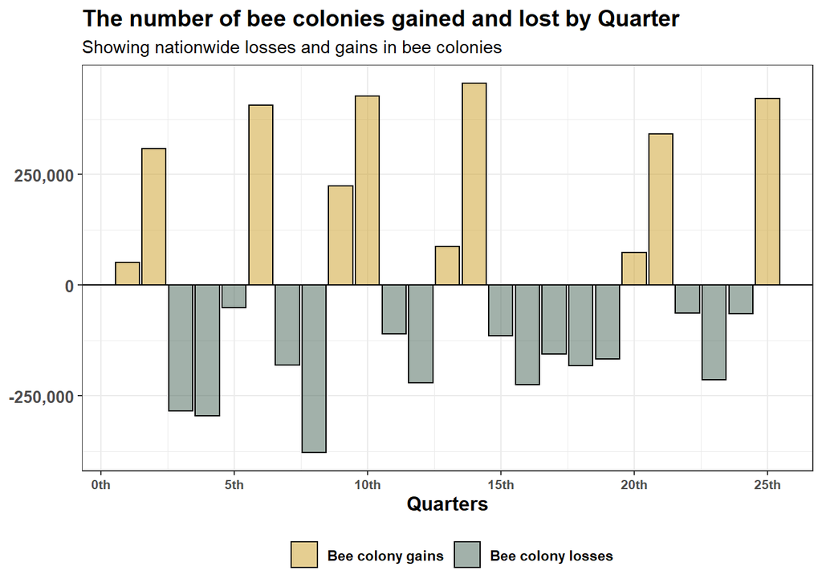

```r
bees %>%
   select(year, months, colony_added, colony_lost) %>%
   distinct() %>%
   group_by(year, months) %>%
   mutate(colony_added = sum(colony_added),
          colony_lost = sum(colony_lost)) %>%
   ungroup() %>% distinct() %>%
   mutate(net_gain = colony_added - colony_lost) %>%
   mutate(Quarters = seq(colony_added)) %>%
   mutate(above_zero = net_gain < 0) %>%
   ggplot(aes(x = Quarters, y = net_gain, fill = above_zero)) +
   geom_col(alpha = 0.5, colour = "black") +
   geom_hline(yintercept = 0) +
   theme_bw() +
   scale_fill_manual(values = c("#CB9E23", "#456355"),
                     labels = c("Bee colony gains", "Bee colony losses")) +
   scale_y_continuous(labels = label_comma()) +
   scale_x_continuous(labels = label_ordinal()) +
   labs(y = NULL,
        title = "The number of bee colonies gained and lost by Quarter",
        subtitle = "Showing nationwide losses and gains in bee colonies") +
   theme(axis.title.x = element_text(size = 12, face = "bold"),
         axis.text.x = element_text(size = 8, face = "bold"),
         axis.text.y = element_text(size = 10, face = "bold"),
         plot.title = element_text(size = 14, face = "bold"),
         legend.text = element_text(face = "bold"),
         legend.title = element_blank(),
         legend.position = "bottom")
```

We have seen that bee colonies are under threat but have been kept from a catastrophic decline by the efforts of bee-keepers. We might now wonder whether there is any difference from state to state. Are some states blessed with environmental conditions that make it easier to maintain healthy colonies of bees? Does the quality of bee-keeping vary across states?

To answer these questions, let’s look at all states that have housed a total more than half a million bee colonies across the time period covered by our data.

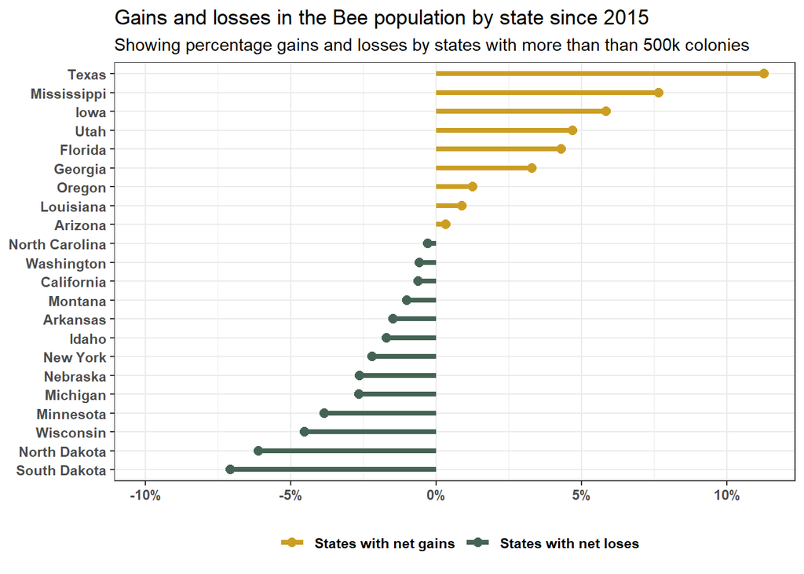

```r
bees %>%
   select(state, colony_n, colony_lost, colony_added) %>%
   distinct() %>%
   group_by(state) %>%
   mutate(total_colonies = sum(colony_n, na.rm = TRUE),
          total_added = sum(colony_added, na.rm = TRUE),
          total_lost = sum(colony_lost, na.rm = TRUE)) %>%
   select(state, starts_with("total_")) %>%
   ungroup() %>% distinct() %>%
   filter(total_colonies > 5e5) %>%
   mutate(percent_change = (total_added - total_lost) / total_colonies,
          state = fct_reorder(state, percent_change),
          pos = percent_change < 0) %>%
   ggplot(aes(x = state, y = percent_change)) +
   geom_point(aes(colour = pos), size = 2.5) +
   geom_segment(aes(x = state, xend = state, y = 0, yend = percent_change, colour = pos), size = 1.5) +
   scale_y_continuous(limits = c(-0.1, NA), labels = label_percent()) +
   scale_colour_manual(values = c("#CB9E23", "#456355"),
                     labels = c("States with net gains", "States with net loses")) +
   labs(x = NULL, y = NULL,
        title = "Gains and losses in the Bee population by state since 2015",
        subtitle = "Showing percentage gains and losses by states with more than than 500k colonies") +
   theme_bw() +
   theme(axis.text.x = element_text(face = "bold"),
         axis.text.y = element_text(face = "bold"),
         legend.text = element_text(face = "bold"),
         legend.title = element_blank(),
         legend.position = "bottom") +
   coord_flip()
```